# Fertility and Reproductive Timing among Women in Nigeria

Findings from the 2018 Demographic and Health Survey

GRAPH Courses Team

Dec 24, 2022

# Fertility

Across the 41,821 surveyed women (ages 15 to 49), 29,992, (71.7%) had at least one child.

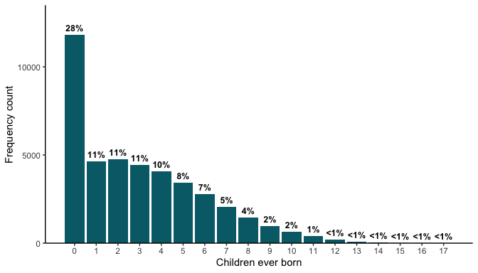

Distribution of the number of children born among surveyed women.

Figure 1 shows the distribution of the number of children per women. The mean number of children ever born was 3.05, with a standard deviation of 2.96.

# Age at first sex, marriage and birth

The overall median age of first sex was 16 years, while the median first cohabitation was 18 years, and the median for first birth was 19 years.

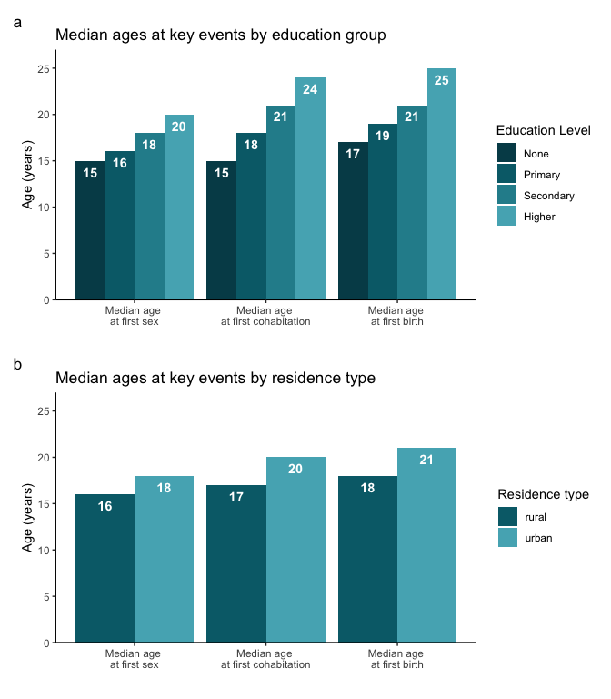

Median ages at first sex, cohabitation and birth by education level and residence type.Cohabitation refers to people living together, either in a formal marraige or in an informal union

Figure 2 shows median ages at key life events by education group and residence type. In general, women with more education had first sex, first cohabitation and first birth later than those with less education. Women in urban areas also experienced these events later than those living in rural areas.

# Teenage Fertility

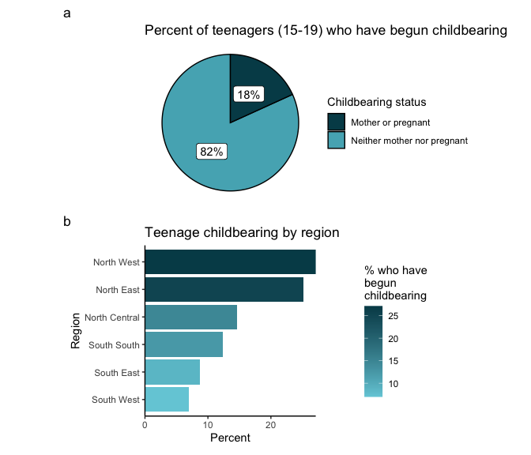

Percentage of teenage women ages 15 to 19 who have begun childbearing, overall and by region.A womam who has begun childbearing has had a child or is currently pregnant.

Figure 3 shows the percentage of teenage women who have begun childbearing, overall and by region. Out of 8,423 teenage women (15-19) surveyed, 1,534 (18.2 %) are mothers or pregnant with their first child. By region, the teenage childbearing rate ranges from 27% in North West to 7% in South West.